# Loading Microbiome Data

Back to Table of Contents

**All of the code in this page is meant to be run in `R` unless otherwise specified.**

After you have installed QIIME and generated an OTU table, you can load the OTU table into R.

Install biom package if not installed.

```r
install.packages('biom',repo='http://cran.wustl.edu')
```

Convert BIOM file to JSON format.  
If you have data in a “new” BIOM format (HDF5), you first need to convert to JSON format first.

**The following code is to be run on the command line.**

```bash
# (Run on on the command-line, in the course repo)
# make a JSON-formatted OTU table for loading into R
cd data/globalgut-66-adults
biom convert -i otu_table.biom -o otu_table_json.biom --to-json
```

Load global gut data using biom package

```r
gg.otus.biom <- read_biom('../data/globalgut-66-adults/otu_table_json.biom')
```

Extract data matrix (OTU counts) from biom table

```r
gg.otus <- as.matrix(biom_data(gg.otus.biom))

# transpose so that rows are samples and columns are OTUs
gg.otus <- t(gg.otus)
```

Plot histogram of sample depths

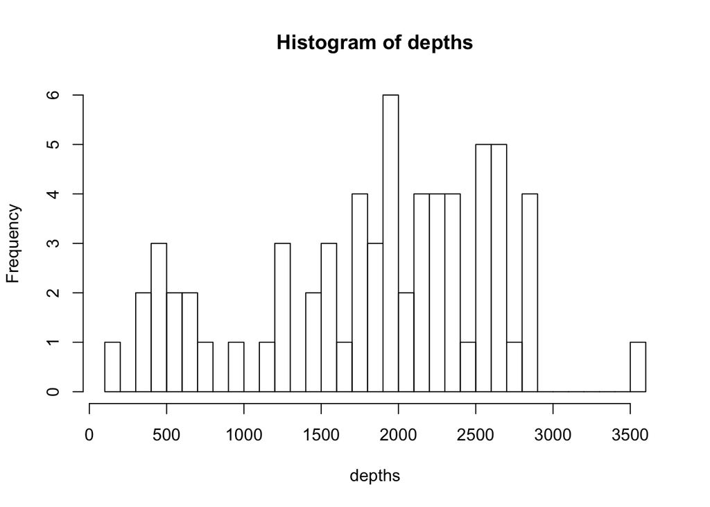

```r
depths <- rowSums(gg.otus)
hist(depths,breaks=30)
```

Plot histogram of OTU frequencies

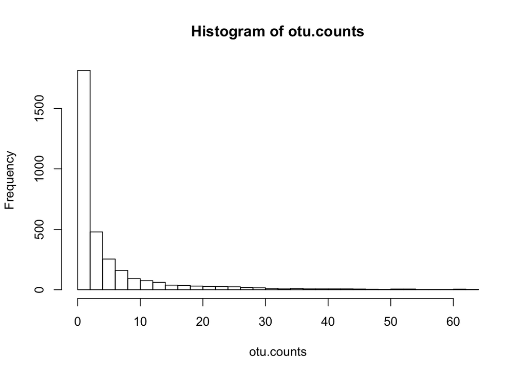

```r
otu.counts <- colSums(gg.otus > 0)
hist(otu.counts,breaks=30)
```

Remove OTUs present in < 10% of samples

```r
gg.otus <- gg.otus[,colMeans(gg.otus > 0) >= .1]
depths <- rowSums(gg.otus)
dim(gg.otus)
```

```
## [1]  66 699
```

Re-plot histogram of OTU frequencies now that we removed singletons

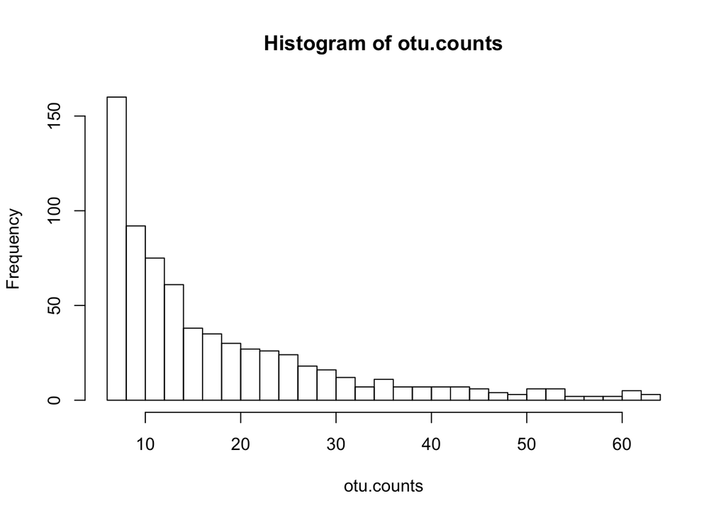

```r
otu.counts <- colSums(gg.otus > 0)
hist(otu.counts,breaks=30)
```

Remove any samples with very low depth

```r
sort(depths)[1:10]
```

```
##   Amz33eld.418866  Amz24chld.418412  Amz31adlt.418759  Amz7adltF.418395
##               125               336               361               398
##   Amz6teen.418569  Amz23chld.418722   Amz6eldM.418356  Amz25chld.418466
##               408               460               480               563
## Amz5chldF1.418757   Amz6eldF.418597
##               587               638
```

```r
gg.otus <- gg.otus[depths >= 1000,]
dim(gg.otus)
```

```
## [1]  53 699
```

Load mapping file

```r
gg.map <- read.table('../data/globalgut-66-adults/map.txt',sep='\t',head=T,row=1,check=F,comment='')
```

Ensure that mapping file and OTU table contain the sample samples in the same order

```r
sample.ids <- intersect(rownames(gg.otus), rownames(gg.map))

# might as well put the samples in alphabetical order
sample.ids <- sort(sample.ids)

# in R you can subset using sample IDs or numerical indices. Most languages only use indices.
gg.otus <- gg.otus[sample.ids,]
gg.map <- gg.map[sample.ids,]
dim(gg.otus)
```

```
## [1]  53 699
```

```r
dim(gg.map)
```

```
## [1] 53 22
```